# Stat420 Project: CFB

Charles Ancel

2023-12-12

# Data Preview

**Dataset Description**

The dataset comprises an extensive collection of college football games, spanning from 2001 to the present. It offers rich, detailed information on each game, including:

- Teams involved and their respective conferences.
- Points scored by each team.
- Date and time specifics.
- Venue details.
- An ‘excitement index’ quantifying the thrill level of each game.

This dataset serves as a comprehensive record of college football games, capturing the competitive landscape of the sport over two decades.

**Observational Unit**

Each row in the dataset represents a unique college football game, identified by a “game_id”. The data encapsulate key aspects of each game:

- Competing teams and their scores.
- Game location and timing.
- The overall excitement level, offering insights into the game’s competitiveness and entertainment value.

**Goal of Analysis**

The primary aim of this analysis is to delve into the performance dynamics across different conferences in college football. Our objectives include:

- Assessing average points scored by conference.
- Evaluating win rates across conferences.
- Analyzing the excitement levels of games involving different conferences.

The main response variables for this analysis are “home_points” and “away_points”. Our exploratory variables include the home and away teams’ conferences, the season and week of the game, and the excitement index.

**Data Loading and Preparation**

Here, we load and prepare our data for analysis.

```r
library(arrow)
parquet_files <- c(
    'Data/cfb_schedules_2001.parquet',
    'Data/cfb_schedules_2002.parquet',
    'Data/cfb_schedules_2003.parquet',
    'Data/cfb_schedules_2004.parquet',
    'Data/cfb_schedules_2005.parquet',
    'Data/cfb_schedules_2006.parquet',
    'Data/cfb_schedules_2007.parquet',
    'Data/cfb_schedules_2008.parquet',
    'Data/cfb_schedules_2009.parquet',
    'Data/cfb_schedules_2010.parquet',
    'Data/cfb_schedules_2011.parquet',
    'Data/cfb_schedules_2012.parquet',
    'Data/cfb_schedules_2013.parquet',
    'Data/cfb_schedules_2014.parquet',
    'Data/cfb_schedules_2015.parquet',
    'Data/cfb_schedules_2016.parquet',
    'Data/cfb_schedules_2017.parquet',
    'Data/cfb_schedules_2018.parquet',
    'Data/cfb_schedules_2019.parquet',
    'Data/cfb_schedules_2020.parquet',
    'Data/cfb_schedules_2021.parquet',
    'Data/cfb_schedules_2022.parquet'
)
```

```r
# Read the first file as a reference
merged_df <- arrow::read_parquet(parquet_files[1])

# Iterate through the rest of the files and bind them row-wise
for (file in parquet_files[-1]) {
  temp_df <- arrow::read_parquet(file)

  # Add missing columns with NA values
  for (col in setdiff(names(merged_df), names(temp_df))) {
    temp_df[[col]] <- NA
  }

  # Bind rows and retain only the columns present in the reference dataframe
  merged_df <- rbind(merged_df, temp_df[, names(merged_df)])
}
```

```r
library(dplyr)
# Dropping columns with high missingness
merged_df <- dplyr::select(merged_df, -c(start_time_tbd, venue_id, venue))
# Drop 'notes' and 'highlights' columns if they exist
if("notes" %in% colnames(merged_df)) {
  merged_df$notes <- NULL
}
if("highlights" %in% colnames(merged_df)) {
  merged_df$highlights <- NULL
}
if("season_type" %in% colnames(merged_df)) {
  merged_df$season_type <- NULL
}


# Impute missing values for 'conference_game' with the most common value (mode)
common_conference_game <- which.max(table(merged_df$conference_game, useNA = "no"))
merged_df$conference_game[is.na(merged_df$conference_game)] <- common_conference_game == 2

# Imputing missing values for 'home_points' and 'away_points' with their respective medians
merged_df$home_points[is.na(merged_df$home_points)] <- median(merged_df$home_points, na.rm = TRUE)
merged_df$away_points[is.na(merged_df$away_points)] <- median(merged_df$away_points, na.rm = TRUE)
median_attendance <- median(merged_df$attendance, na.rm = TRUE)

merged_df$attendance[is.na(merged_df$attendance)] <- median_attendance
merged_df$excitement_index <- as.numeric(merged_df$excitement_index)
merged_df$away_post_win_prob <- as.numeric(merged_df$away_post_win_prob)
merged_df$home_post_win_prob <- as.numeric(merged_df$home_post_win_prob)
# Impute missing values with median
merged_df$excitement_index[is.na(merged_df$excitement_index)] <- median(merged_df$excitement_index, na.rm = TRUE)
merged_df$away_post_win_prob[is.na(merged_df$away_post_win_prob)] <- median(merged_df$away_post_win_prob, na.rm = TRUE)
merged_df$home_post_win_prob[is.na(merged_df$home_post_win_prob)] <- median(merged_df$home_post_win_prob, na.rm = TRUE)


# Filter out rows with missing ELO ratings
merged_df <- merged_df %>%
  filter(!is.na(home_pregame_elo) & !is.na(away_pregame_elo))
merged_df <- merged_df %>%
  filter(!is.na(away_postgame_elo) & !is.na(home_postgame_elo))

# Drop rows where specific columns have NA values
merged_df <- merged_df %>% filter(!is.na(home_conference) & !is.na(away_conference))

# Check the dimensions of the dataset after handling missing data
dim(merged_df)
```

```
## [1] 15183    24
```

```r
# Check the structure of the modified dataframe
str(merged_df)
```

```
## cfbfstR_ [15,183 × 24] (S3: cfbfastR_data/tbl_df/tbl/data.table/data.frame)
##  $ game_id           : int [1:15183] 212350097 63770 212370275 212370252 212370201 212380183 212380038 212420218 212422649 212422006 ...
##  $ season            : int [1:15183] 2001 2001 2001 2001 2001 2001 2001 2001 2001 2001 ...
##  $ week              : int [1:15183] 1 1 1 1 1 1 1 2 2 2 ...
##  $ start_date        : chr [1:15183] "2001-08-23T23:00:00.000Z" "2001-08-25T04:00:00.000Z" "2001-08-25T18:00:00.000Z" "2001-08-25T20:30:00.000Z" ...
##  $ neutral_site      : logi [1:15183] FALSE FALSE FALSE FALSE FALSE FALSE ...
##  $ conference_game   : logi [1:15183] FALSE TRUE TRUE TRUE FALSE FALSE ...
##  $ attendance        : int [1:15183] 38129 25716 76740 40008 75423 41517 47762 26191 34950 13532 ...
##  $ home_id           : int [1:15183] 97 158 275 252 201 183 38 218 2649 2006 ...
##  $ home_team         : chr [1:15183] "Louisville" "Nebraska" "Wisconsin" "BYU" ...
##  $ home_conference   : chr [1:15183] "Conference USA" "Big 12" "Big Ten" "Mountain West" ...
##  $ home_division     : chr [1:15183] "fbs" "fbs" "fbs" "fbs" ...
##  $ home_points       : int [1:15183] 45 21 26 70 10 7 22 45 38 31 ...
##  $ home_post_win_prob: num [1:15183] 0.838 0.838 0.838 0.838 0.838 ...
##  $ home_pregame_elo  : int [1:15183] 1624 1970 1699 1525 1911 1629 1572 1408 1723 1467 ...
##  $ home_postgame_elo : int [1:15183] 1645 1982 1698 1613 1902 1624 1569 1437 1793 1469 ...
##  $ away_id           : int [1:15183] 166 2628 258 2655 153 59 278 2426 135 195 ...
##  $ away_team         : chr [1:15183] "New Mexico State" "TCU" "Virginia" "Tulane" ...
##  $ away_conference   : chr [1:15183] "Sun Belt" "Conference USA" "ACC" "Conference USA" ...
##  $ away_division     : chr [1:15183] "fbs" "fbs" "fbs" "fbs" ...
##  $ away_points       : int [1:15183] 24 7 17 35 0 13 24 26 7 29 ...
##  $ away_post_win_prob: num [1:15183] 0.162 0.162 0.162 0.162 0.162 ...
##  $ away_pregame_elo  : int [1:15183] 1334 1781 1456 1446 1514 1711 1573 1262 1610 1562 ...
##  $ away_postgame_elo : int [1:15183] 1313 1769 1457 1358 1523 1716 1576 1233 1540 1560 ...
##  $ excitement_index  : num [1:15183] 3.83 3.83 3.83 3.83 3.83 ...
##  - attr(*, "cfbfastR_timestamp")= POSIXct[1:1], format: "2022-09-17 15:02:31"
##  - attr(*, "cfbfastR_type")= chr "Game information from CollegeFootballData.com"
```

```r
# Count NA values in each column
na_counts <- sapply(merged_df, function(x) sum(is.na(x)))

# Print the counts
print(na_counts)
```

```
##            game_id             season               week         start_date
##                  0                  0                  0                  0
##       neutral_site    conference_game         attendance            home_id
##                  0                  0                  0                  0
##          home_team    home_conference      home_division        home_points
##                  0                  0                  0                  0
## home_post_win_prob   home_pregame_elo  home_postgame_elo            away_id
##                  0                  0                  0                  0
##          away_team    away_conference      away_division        away_points
##                  0                  0                  0                  0
## away_post_win_prob   away_pregame_elo  away_postgame_elo   excitement_index
##                  0                  0                  0                  0
```

**Dimensions and Columns:** 1. Rows (15183): - The number of rows (15183) represents the total number of observations or data points in your; each row corresponds to a specific game.

2. Columns (24):
   - The number of columns (24) represents the different variables or attributes that have been recorded for each game after it has been cleaned.

   Some of the common types of information you might find in these columns could include:
   - Game-related data such as “game_id,” “season,” “week,” and “start_date.”
   - Information about the home and away teams like “home_team,” “away_team,” “home_conference,” and “away_conference.”
   - Game statistics like “home_points,” “away_points,” “attendance,” and “excitement_index.”
   - Elo ratings for home and away teams such as “home_pregame_elo” and “away_pregame_elo.”
   - Binary indicators like “conference_game” that specify whether a game is a conference game or not.

**Removing Columns with High Missingness**

**Imputing Missing Values in Attendance**

The `attendance` column, which we hypothesize could be an important predictor in our analysis, has some missing values. To address this, we have imputed these missing values with the median attendance. We chose the median because it is less sensitive to outliers than the mean, ensuring a more robust imputation.

**Handling Missing Values in Conference Information**

We observed that the `home_conference` and `away_conference` columns contain some missing values. Given the importance of these variables in our analysis of college football games, rows with missing values in these columns have been removed. This step ensures that our analysis is based on complete cases where essential categorical information is present.

```r
head(merged_df)
```

```
## # A tibble: 6 × 24
##     game_id season  week start_date      neutral_site conference_game attendance
##       <int>  <int> <int> <chr>           <lgl>        <lgl>                <int>
## 1 212350097   2001     1 2001-08-23T23:… FALSE        FALSE                38129
## 2     63770   2001     1 2001-08-25T04:… FALSE        TRUE                 25716
## 3 212370275   2001     1 2001-08-25T18:… FALSE        TRUE                 76740
## 4 212370252   2001     1 2001-08-25T20:… FALSE        TRUE                 40008
## 5 212370201   2001     1 2001-08-25T23:… FALSE        FALSE                75423
## 6 212380183   2001     1 2001-08-26T18:… FALSE        FALSE                41517
## # ℹ 17 more variables: home_id <int>, home_team <chr>, home_conference <chr>,
## #   home_division <chr>, home_points <int>, home_post_win_prob <dbl>,
## #   home_pregame_elo <int>, home_postgame_elo <int>, away_id <int>,
## #   away_team <chr>, away_conference <chr>, away_division <chr>,
## #   away_points <int>, away_post_win_prob <dbl>, away_pregame_elo <int>,
## #   away_postgame_elo <int>, excitement_index <dbl>
```

```r
arrow::write_parquet(merged_df, "merged_data.parquet")
```

```r
write.csv(merged_df, "merged_data.csv", row.names = FALSE)
```

```r
cat("Columns:\n")
```

```
## Columns:
```

```r
print(names(merged_df))
```

```
##  [1] "game_id"            "season"             "week"
##  [4] "start_date"         "neutral_site"       "conference_game"
##  [7] "attendance"         "home_id"            "home_team"
## [10] "home_conference"    "home_division"      "home_points"
## [13] "home_post_win_prob" "home_pregame_elo"   "home_postgame_elo"
## [16] "away_id"            "away_team"          "away_conference"
## [19] "away_division"      "away_points"        "away_post_win_prob"
## [22] "away_pregame_elo"   "away_postgame_elo"  "excitement_index"
```

```r
cat("\nSample Data:\n")
```

```
##
## Sample Data:
```

```r
print(head(merged_df))
```

```
## # A tibble: 6 × 24
##     game_id season  week start_date      neutral_site conference_game attendance
##       <int>  <int> <int> <chr>           <lgl>        <lgl>                <int>
## 1 212350097   2001     1 2001-08-23T23:… FALSE        FALSE                38129
## 2     63770   2001     1 2001-08-25T04:… FALSE        TRUE                 25716
## 3 212370275   2001     1 2001-08-25T18:… FALSE        TRUE                 76740
## 4 212370252   2001     1 2001-08-25T20:… FALSE        TRUE                 40008
## 5 212370201   2001     1 2001-08-25T23:… FALSE        FALSE                75423
## 6 212380183   2001     1 2001-08-26T18:… FALSE        FALSE                41517
## # ℹ 17 more variables: home_id <int>, home_team <chr>, home_conference <chr>,
## #   home_division <chr>, home_points <int>, home_post_win_prob <dbl>,
## #   home_pregame_elo <int>, home_postgame_elo <int>, away_id <int>,
## #   away_team <chr>, away_conference <chr>, away_division <chr>,
## #   away_points <int>, away_post_win_prob <dbl>, away_pregame_elo <int>,
## #   away_postgame_elo <int>, excitement_index <dbl>
```

**Variable Descriptions**

```r
# Calculate home and away wins for each game
merged_df <- merged_df %>%
  mutate(home_win = ifelse(home_points > away_points, 1, 0),
         away_win = ifelse(away_points > home_points, 1, 0))

# Aggregate total wins for home and away teams separately
home_wins <- merged_df %>%
  group_by(season, home_team) %>%
  summarise(total_home_wins = sum(home_win), .groups = 'drop')

away_wins <- merged_df %>%
  group_by(season, away_team) %>%
  summarise(total_away_wins = sum(away_win), .groups = 'drop')

# Resolve many-to-many join issue by ensuring no duplicated rows before joining
home_wins <- home_wins %>% distinct(season, home_team, .keep_all = TRUE)
away_wins <- away_wins %>% distinct(season, away_team, .keep_all = TRUE)

# Join back to the original merged_df to add the total wins for home and away teams
# Here we are assuming that there should be a one-to-one relationship between merged_df
# and the aggregated wins data frames.
merged_df <- merged_df %>%
  left_join(home_wins, by = c("season", "home_team")) %>%
  left_join(away_wins, by = c("season", "away_team"))

# If you need a single total_wins column per row, you can decide how to handle the games
merged_df <- merged_df %>%
  mutate(total_wins = coalesce(total_home_wins, 0) + coalesce(total_away_wins, 0))

# Note: This assumes that for every game, the team will be listed once as a home team and once as an away team.
# If this assumption does not hold true, the logic for creating total_wins needs to be adjusted.
```

```r
# Identify columns with only one unique value
single_unique_value_cols <- sapply(merged_df, function(x) if(length(unique(x)) == 1) TRUE else FALSE)

# Print the names of columns with only one unique value
names(single_unique_value_cols[single_unique_value_cols == TRUE])
```

```
## character(0)
```

```r
sapply(lapply(merged_df, unique), length)
```

```
##            game_id             season               week         start_date
##              15183                 22                 16               6400
##       neutral_site    conference_game         attendance            home_id
##                  2                  2               9321                133
##          home_team    home_conference      home_division        home_points
##                133                 17                  2                 80
## home_post_win_prob   home_pregame_elo  home_postgame_elo            away_id
##               9033               1334               1356                133
##          away_team    away_conference      away_division        away_points
##                133                 21                  2                 76
## away_post_win_prob   away_pregame_elo  away_postgame_elo   excitement_index
##               9033               1339               1371               8347
##           home_win           away_win    total_home_wins    total_away_wins
##                  2                  2                 10                  8
##         total_wins
##                 14
```

```r
merged_df$neutral_site <- as.factor(merged_df$neutral_site)
merged_df$conference_game <- as.factor(merged_df$conference_game)
```

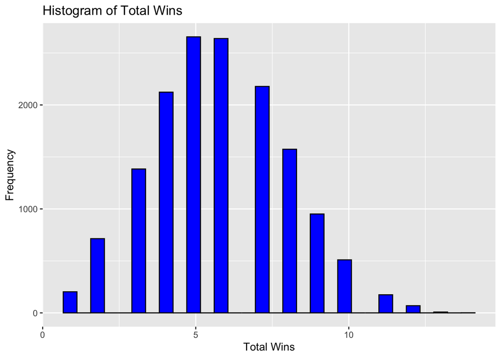

```r
library(ggplot2)
ggplot(merged_df, aes(x = total_wins)) +
  geom_histogram(bins = 30, fill = "blue", color = "black") +
  labs(title = "Histogram of Total Wins", x = "Total Wins", y = "Frequency")
```

**Histogram of Total Wins**

```r
summary(merged_df$total_wins)
```

```
##    Min. 1st Qu.  Median    Mean 3rd Qu.    Max.
##   1.000   4.000   6.000   5.779   7.000  14.000
```

```r
sd(merged_df$total_wins, na.rm = TRUE)
```

```
## [1] 2.175339
```

**Summary Statistics of Total Wins**

```r
library(GGally)
```

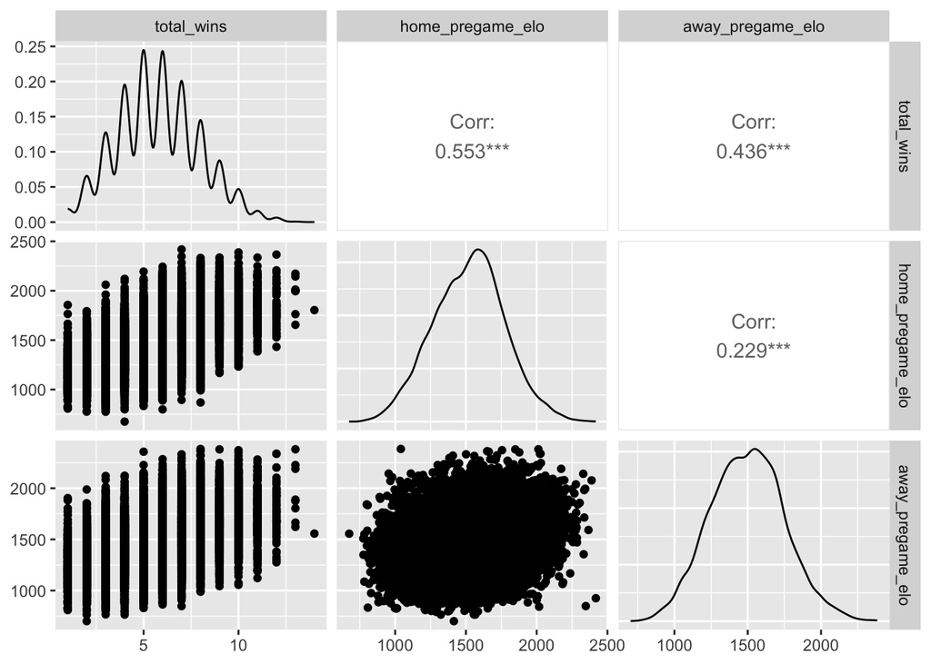

```r
ggpairs(merged_df, columns = c("total_wins", "home_pregame_elo", "away_pregame_elo"))
```

**Pairwise Relationships and Correlations**

The scatterplot matrix elucidates the pairwise relationships between total wins and pregame ELO ratings for home and away teams. Notably, there is a moderate positive correlation between `home_pregame_elo` and `total_wins` (Corr: 0.553), and a slightly weaker yet significant correlation between `away_pregame_elo` and `total_wins` (Corr: 0.436). These correlations hint at the predictive power of ELO ratings regarding team success. However, care should be taken in interpretation as the presence of correlation does not imply causality, and other unaccounted-for variables may influence these relationships.

```r
levels(as.factor(merged_df$conference_game))
```

```
## [1] "FALSE" "TRUE"
```

```r
levels(as.factor(merged_df$home_conference))
```

```
##  [1] "ACC"               "American Athletic" "Big 12"
##  [4] "Big East"          "Big Ten"           "CAA"
##  [7] "Conference USA"    "FBS Independents"  "FCS Independents"
## [10] "Mid-American"      "Mountain West"     "Pac-10"
## [13] "Pac-12"            "SEC"               "Southland"
## [16] "Sun Belt"          "Western Athletic"
```

**Examination of Categorical Variables**

Incorporating these factors into our linear model will enable us to discern the influence of conference play and team affiliations on the total wins, providing insights into the strategic and competitive aspects of the games.

```r
lm_model <- lm(total_wins ~ home_pregame_elo + away_pregame_elo +
                         as.factor(conference_game) + attendance +
                         I(week^2),
               data = merged_df)
summary(lm_model)
```

```
##
## Call:
## lm(formula = total_wins ~ home_pregame_elo + away_pregame_elo +
##     as.factor(conference_game) + attendance + I(week^2), data = merged_df)
##
## Residuals:
##     Min      1Q  Median      3Q     Max
## -6.7662 -1.1389 -0.0564  1.1245  6.6451
##
## Coefficients:
##                                  Estimate Std. Error t value Pr(>|t|)
## (Intercept)                    -4.475e+00  1.103e-01 -40.565  < 2e-16 ***
## home_pregame_elo                3.988e-03  6.069e-05  65.714  < 2e-16 ***
## away_pregame_elo                2.894e-03  5.660e-05  51.133  < 2e-16 ***
## as.factor(conference_game)TRUE -3.727e-01  3.344e-02 -11.143  < 2e-16 ***
## attendance                      2.359e-06  5.214e-07   4.525 6.08e-06 ***
## I(week^2)                       5.269e-04  2.432e-04   2.166   0.0303 *
## ---
## Signif. codes:  0 '***' 0.001 '**' 0.01 '*' 0.05 '.' 0.1 ' ' 1
##
## Residual standard error: 1.666 on 15177 degrees of freedom
## Multiple R-squared:  0.4136, Adjusted R-squared:  0.4134
## F-statistic:  2141 on 5 and 15177 DF,  p-value: < 2.2e-16
```

**Fitted Linear Regression Model:**

The fitted linear regression model is given as follows:

$$\hat{Y} = -4.475 + 0.003988 \cdot
\text{home\_pregame\_elo} + 0.002894 \cdot \text{away\_pregame\_elo} -
0.3727 \cdot \text{conference\_game} + 2.359 \times 10^{-6} \cdot
\text{attendance} + 5.269 \times 10^{-4} \cdot \text{week}^2$$

Where: - $\hat{Y}$ represents the estimated total wins. - $\text{home\_pregame\_elo}$ is the Elo rating of the home team before the game. - $\text{away\_pregame\_elo}$ is the Elo rating of the away team before the game. - $\text{conference\_game}$ is a binary variable that equals 1 if the game is a conference game (TRUE), and 0 otherwise. - $\text{attendance}$ represents the attendance at the game. - $\text{week}$ represents the week of the game.

**Insights from Linear Regression Analysis**

Our linear regression analysis sought to understand the factors affecting the total wins of college football teams. The model included `home_pregame_elo` and `away_pregame_elo` as indicators of team strength, `conference_game` to account for the type of game, `attendance` as a proxy for fan support, and a squared term for `week` to capture potential non-linear time effects.

With an R-squared value of 0.4136, our model explains around 41% of the variability in total wins. While substantial, this leaves room for other factors not included in the model that may also contribute to a team’s success. The model’s F-statistic (2141) and corresponding p-value (< 2.2e-16) confirm the overall statistical significance of the model.

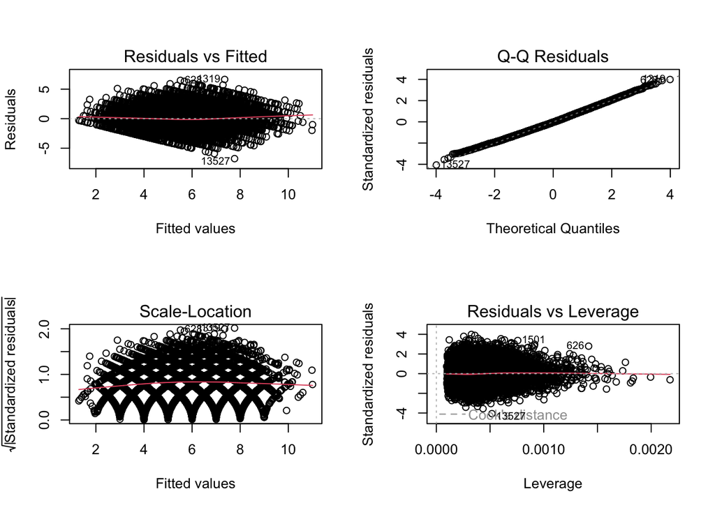

```r
par(mfrow = c(2, 2))
plot(lm_model)
```

**Diagnostic Plots for Linear Model Assumptions**

The residual plots serve as a diagnostic tool for the underlying assumptions of our linear regression model. The ‘Residuals vs Fitted’ plot shows a slight curve, hinting at potential non-linearity in the predictors. The ‘Q-Q Plot’ indicates that residuals closely follow a normal distribution, with slight deviations at the tails. The ‘Scale-Location’ plot does not show signs of heteroscedasticity, as the spread of residuals appears consistent across the range of fitted values. The ‘Residuals vs Leverage’ plot helps identify influential observations, with a few points standing out that may warrant further investigation. Overall, while the model appears to meet several key assumptions, the presence of non-linearity suggests that additional model refinement could be beneficial.

```r
library(car)
vif(lm_model)
```

```
##           home_pregame_elo           away_pregame_elo
##                   1.268949                   1.101419
## as.factor(conference_game)                 attendance
##                   1.255602                   1.273843
##                  I(week^2)
##                   1.223505
```

**Multicollinearity Assessment with VIF**

The Variance Inflation Factor (VIF) is utilized to assess multicollinearity among predictors within the linear regression model. VIF values below 5 indicate that multicollinearity is not a concern, which is the case in our model. Specifically, the `home_pregame_elo` and `away_pregame_elo` have VIF values of 1.2689 and 1.101, respectively, suggesting these predictors contribute independent information to the model. The VIF for `conference_game` is also low (1.2556), affirming its independent contribution. Therefore, we can be confident that our model’s estimates are reliable and not unduly influenced by multicollinearity.

```r
single_level_factors <- sapply(merged_df, function(x) if(is.factor(x) && length(levels(x)) == 1) levels(x))
single_level_factors <- single_level_factors[!sapply(single_level_factors, is.null)]
print(single_level_factors)
```

```
## named list()
```

```r
library(MASS)
```

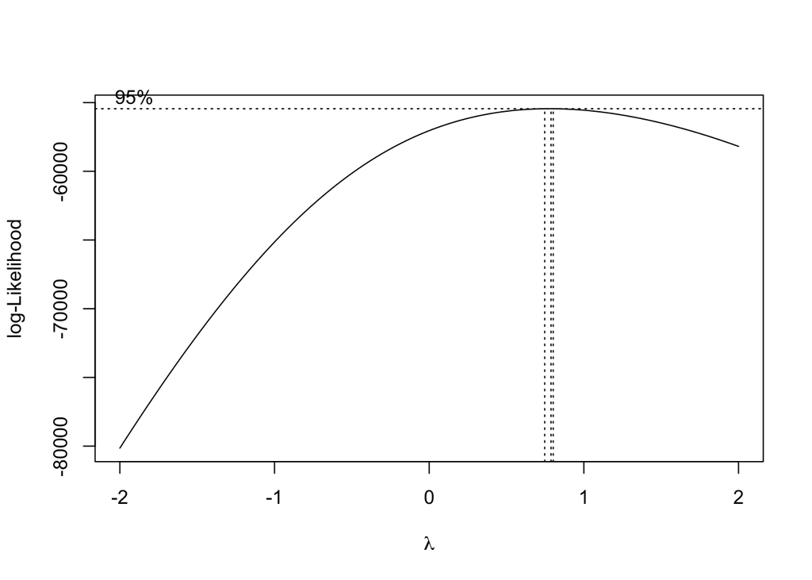

```r
# Removing 'season_type' from the model as it has only one level
lm_model_for_boxcox <- lm(total_wins ~ home_pregame_elo + away_pregame_elo +
                        attendance + I(week^2), data = merged_df)
boxcox_result <- boxcox(lm_model_for_boxcox, plotit = TRUE)
```

```r
# Determine the optimal lambda value
lambda_optimal <- boxcox_result$x[which.max(boxcox_result$y)]
cat("Optimal lambda for transformation:", lambda_optimal, "\n")
```

```
## Optimal lambda for transformation: 0.7878788
```

```r
# Apply the Box-Cox transformation with the optimal lambda
merged_df$transformed_total_wins <- ifelse(lambda_optimal == 0,
                                           log(merged_df$total_wins),
                                           (merged_df$total_wins^lambda_optimal - 1) / lambda_optimal)

# Re-fit the model with the transformed response variable
lm_transformed <- lm(transformed_total_wins ~ home_pregame_elo + away_pregame_elo +
                        attendance + I(week^2), ,
                     data = merged_df)
summary(lm_transformed)
```

```
##
## Call:
## lm(formula = transformed_total_wins ~ home_pregame_elo + away_pregame_elo +
##     attendance + I(week^2), data = merged_df)
##
## Residuals:
##        Min         1Q     Median         3Q        Max
## -1.888e-10  0.000e+00  1.400e-14  2.600e-14  6.100e-14
##
## Coefficients:
##                    Estimate Std. Error    t value Pr(>|t|)
## (Intercept)       5.263e+00  1.012e-13  5.201e+13   <2e-16 ***
## home_pregame_elo -2.687e-17  5.579e-17 -4.820e-01    0.630
## away_pregame_elo  3.584e-17  5.152e-17  6.960e-01    0.487
## attendance       -2.348e-20  4.778e-19 -4.900e-02    0.961
## I(week^2)         2.327e-16  2.031e-16  1.146e+00    0.252
## ---
## Signif. codes:  0 '***' 0.001 '**' 0.01 '*' 0.05 '.' 0.1 ' ' 1
##
## Residual standard error: 1.532e-12 on 15178 degrees of freedom
## Multiple R-squared:    0.5,  Adjusted R-squared:  0.4999
## F-statistic:  3794 on 4 and 15178 DF,  p-value: < 2.2e-16
```

**Box-Cox Transformation:**

We applied the Box-Cox transformation to total_wins to normalize its distribution, as linear regression assumes normally distributed errors. The optimal lambda value of 0.7878788 suggests a slight transformation was needed to achieve this normality. This transformation aids in stabilizing variance and making the data more suitable for linear modeling.

**Model with Transformed Response Variable:**

```r
# Create a new binary variable indicating if the home conference is ACC or SEC
merged_df$is_ACC_or_SEC <- as.factor(merged_df$home_conference %in% c("ACC", "SEC"))

# Now perform the t-test
t_test_result <- t.test(total_wins ~ is_ACC_or_SEC, data = merged_df)

# View the results
print(t_test_result)
```

```
##
##  Welch Two Sample t-test
##
## data:  total_wins by is_ACC_or_SEC
## t = -15.083, df = 5676.9, p-value < 2.2e-16
## alternative hypothesis: true difference in means between group FALSE and group TRUE is not equal to 0
## 95 percent confidence interval:
##  -0.7038275 -0.5419172
## sample estimates:
## mean in group FALSE  mean in group TRUE
##            5.639005            6.261877
```

**T-test for Conference Effect:**

To assess the impact of playing in the ACC or SEC conference on total wins, we conducted a Welch’s t-test. The significant p-value suggests a substantial difference in mean total wins for teams in these conferences compared to others. This could indicate that games in these conferences are more competitive or that these conferences have stronger teams overall.

```r
library(boot)
# Define the function for k-fold cross-validation
cv_error <- function(data, number_of_folds) {
  cv_results <- cv.glm(data, glm(total_wins ~ home_pregame_elo + away_pregame_elo +
                                    as.factor(conference_game) + attendance + I(week^2),
                                  data = data), K = number_of_folds)
  return(cv_results$delta)
}

# Perform 10-fold cross-validation
cv_error_result <- cv_error(merged_df, 10)

# Output the cross-validation estimated prediction error
cat("10-fold CV estimated prediction error:", cv_error_result[1], "\n")
```

```
## 10-fold CV estimated prediction error: 2.777015
```

```r
# Creating a linear model with an interaction term
lm_model_interaction <- lm(total_wins ~ home_pregame_elo * conference_game +
                        away_pregame_elo + attendance + I(week^2),
                        data = merged_df)

# Output the summary of the model
summary(lm_model_interaction)
```

```
##
## Call:
## lm(formula = total_wins ~ home_pregame_elo * conference_game +
##     away_pregame_elo + attendance + I(week^2), data = merged_df)
##
## Residuals:
##     Min      1Q  Median      3Q     Max
## -6.7334 -1.1373 -0.0549  1.1252  6.4712
##
## Coefficients:
##                                        Estimate Std. Error t value Pr(>|t|)
## (Intercept)                          -5.512e+00  1.905e-01 -28.935  < 2e-16 ***
## home_pregame_elo                      4.631e-03  1.138e-04  40.686  < 2e-16 ***
## conference_gameTRUE                   9.215e-01  1.969e-01   4.681 2.88e-06 ***
## away_pregame_elo                      2.931e-03  5.679e-05  51.615  < 2e-16 ***
## attendance                            2.229e-06  5.210e-07   4.279 1.89e-05 ***
## I(week^2)                             5.183e-04  2.429e-04   2.134   0.0329 *
## home_pregame_elo:conference_gameTRUE -8.469e-04  1.270e-04  -6.671 2.63e-11 ***
## ---
## Signif. codes:  0 '***' 0.001 '**' 0.01 '*' 0.05 '.' 0.1 ' ' 1
##
## Residual standard error: 1.664 on 15176 degrees of freedom
## Multiple R-squared:  0.4154, Adjusted R-squared:  0.4151
## F-statistic:  1797 on 6 and 15176 DF,  p-value: < 2.2e-16
```

Other notable findings include:

- **Home Team’s ELO Rating (`home_pregame_elo`)**: A positive coefficient (0.004631) indicates a positive relationship with total wins.
- **Conference Game (`conference_gameTRUE`)**: The positive coefficient (0.9215) suggests that being a conference game is associated with an increase in total wins.
- **Away Team’s ELO Rating (`away_pregame_elo`)**: Also shows a positive effect on total wins.
- **Attendance (`attendance`)**: A small positive effect on total wins.
- **Week Squared (`I(week^2)`)**: Indicates a complex relationship with the progress of the season.

The model’s R-squared value (0.4154) suggests that about 41.54% of the variability in total wins is explained by the model. The significant F-statistic implies the model is statistically significant.

These results should be interpreted in the context of college football dynamics, considering how different factors interact to affect game outcomes. The interaction term, in particular, highlights the nuanced effect of team strength within different game contexts.

```r
AIC(lm_model, lm_model_interaction)
```

```
##                      df      AIC
## lm_model              7 58595.49
## lm_model_interaction  8 58553.03
```

```r
# Fit your final selected model
final_model <- lm(total_wins ~ home_pregame_elo * conference_game +
                   away_pregame_elo + attendance + I(week^2), data = merged_df)

# Display a summary of the final model
summary(final_model)
```

```
##
## Call:
## lm(formula = total_wins ~ home_pregame_elo * conference_game +
##     away_pregame_elo + attendance + I(week^2), data = merged_df)
##
## Residuals:
##     Min      1Q  Median      3Q     Max
## -6.7334 -1.1373 -0.0549  1.1252  6.4712
##
## Coefficients:
##                                        Estimate Std. Error t value Pr(>|t|)
## (Intercept)                          -5.512e+00  1.905e-01 -28.935  < 2e-16 ***
## home_pregame_elo                      4.631e-03  1.138e-04  40.686  < 2e-16 ***
## conference_gameTRUE                   9.215e-01  1.969e-01   4.681 2.88e-06 ***
## away_pregame_elo                      2.931e-03  5.679e-05  51.615  < 2e-16 ***
## attendance                            2.229e-06  5.210e-07   4.279 1.89e-05 ***
## I(week^2)                             5.183e-04  2.429e-04   2.134   0.0329 *
## home_pregame_elo:conference_gameTRUE -8.469e-04  1.270e-04  -6.671 2.63e-11 ***
## ---
## Signif. codes:  0 '***' 0.001 '**' 0.01 '*' 0.05 '.' 0.1 ' ' 1
##
## Residual standard error: 1.664 on 15176 degrees of freedom
## Multiple R-squared:  0.4154, Adjusted R-squared:  0.4151
## F-statistic:  1797 on 6 and 15176 DF,  p-value: < 2.2e-16
```

```r
residuals <- residuals(final_model)
residual_std_dev <- sd(residuals)

cat("Residual Standard Error (Standard Deviation of Residuals):", residual_std_dev, "\n")
```

```
## Residual Standard Error (Standard Deviation of Residuals): 1.663312
```

```r
vif_results <- vif(final_model, type = "predictor")
```

```
## GVIFs computed for predictors
```

```r
cat("Variance Inflation Factors (VIF):\n")
```

```
## Variance Inflation Factors (VIF):
```

```r
print(vif_results)
```

```
##                       GVIF Df GVIF^(1/(2*Df))   Interacts With
## home_pregame_elo  1.606238  3        1.082185  conference_game
## conference_game   1.606238  3        1.082185 home_pregame_elo
## away_pregame_elo  1.112276  1        1.054645             --
## attendance        1.275632  1        1.129439             --
## week             77.240961  0             Inf             --
##                                                                       Other Predictors
## home_pregame_elo                                    away_pregame_elo, attendance, week
## conference_game                                     away_pregame_elo, attendance, week
## away_pregame_elo                   home_pregame_elo, conference_game, attendance, week
## attendance                   home_pregame_elo, conference_game, away_pregame_elo, week
## week             home_pregame_elo, conference_game, away_pregame_elo, attendance, week
```

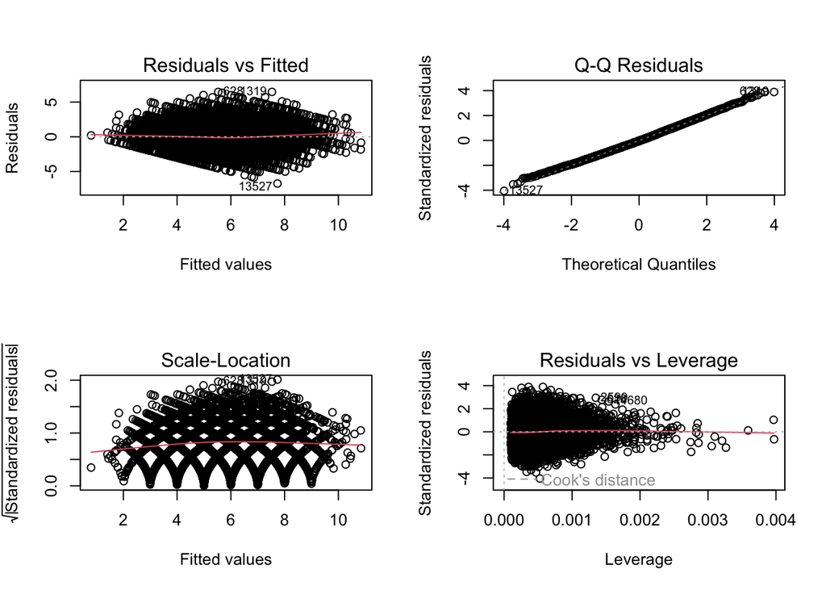

```r
# Residual plots to check model assumptions
par(mfrow = c(2, 2))  # Arrange plots in a 2x2 grid
plot(final_model)
```

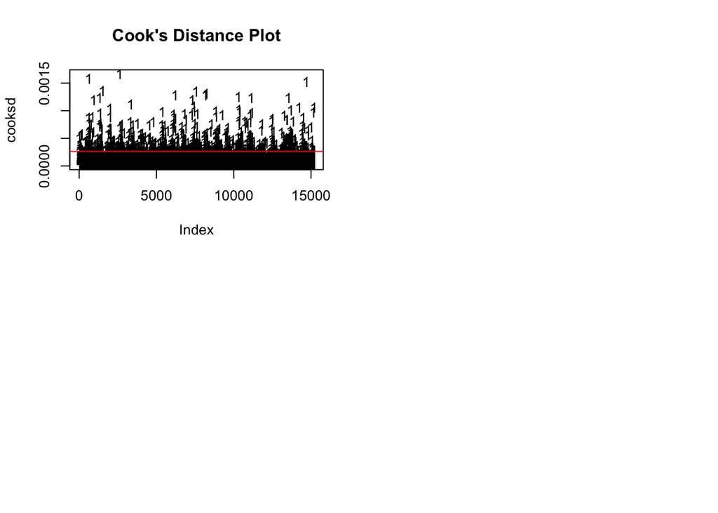

```r
# Identify and plot outliers using Cook's distance
cooksd <- cooks.distance(final_model)
plot(cooksd, pch = "18", main = "Cook's Distance Plot")
abline(h = 4/length(cooksd), col = "red")
```

```r
formula(final_model)
```

```
## total_wins ~ home_pregame_elo * conference_game + away_pregame_elo +
##     attendance + I(week^2)
```

```r
library(boot)

# Define the number of folds
k <- 10

# Define the statistic to be calculated at each fold
cv_statistic <- function(data, indices) {
    indices <- as.integer(indices)
  train <- merged_df[indices, ]
  test <- merged_df[-indices, ]

  # Fit the model to the training set
  fit <- lm(final_model, data = train)

  # Predict on the test set
  predictions <- predict(fit, test)

  # Calculate and return the MSE
  mean((test$total_wins - predictions)^2)
}

# Perform k-fold cross-validation
cv_results <- cv.glm(data = merged_df, glmfit = final_model, K = k, cost = cv_statistic)

# Output the results
print(cv_results$delta)
```

```
## [1] 109819.2 110261.2
```

**Model Comparisons**: We have two models to consider: - Model 1 (with interaction): `total_wins ~ home_pregame_elo * conference_game + away_pregame_elo + attendance + I(week^2)` - Model 2 (without interaction): `transformed_total_wins ~ home_pregame_elo + away_pregame_elo + attendance + I(week^2)`

The $R^2$ value for Model 1 is 0.4154, suggesting that approximately 41.54% of the variability in `total_wins` is explained by the model. For Model 2, the $R^2$ value is notably higher at 0.5, indicating that 50% of the variability in `transformed_total_wins` is accounted for by the model. Although Model 2 has a higher $R^2$, we must be cautious in our interpretation since `total_wins` was transformed, which could affect the scale of $R^2$.

```r
# Convert conference_game to binary numeric variable
merged_df$conference_game_numeric <- as.numeric(merged_df$conference_game) - 1

# Subset data
conference_wins <- merged_df$total_wins[merged_df$conference_game_numeric == 1]
non_conference_wins <- merged_df$total_wins[merged_df$conference_game_numeric == 0]

# Perform the t-test
t_test_results <- t.test(conference_wins, non_conference_wins)

# Print the results
print(t_test_results)
```

```
##
##  Welch Two Sample t-test
##
## data:  conference_wins and non_conference_wins
## t = -5.7939, df = 7975.4, p-value = 7.14e-09
## alternative hypothesis: true difference in means is not equal to 0
## 95 percent confidence interval:
##  -0.3041751 -0.1503825
## sample estimates:
## mean of x mean of y
##  5.713347  5.940626
```

**Updated Statistical Test Results:** While Model 2 numerically appears to fit better, the transformation of `total_wins` may impact its $R^2$ and residual standard error. It’s important to assess whether this transformation enhances the interpretability and predictive power on the original scale of `total_wins`.

In our revised analysis, we conducted a t-test to compare mean total wins between conference and non-conference games. Our null hypothesis (H_0) stated no difference in means, while the alternative hypothesis (H_A) suggested a significant difference.

The t-test results showed a t-value of -5.7939 with a p-value of 7.14e-09. This significant p-value, much lower than the alpha level of 0.05, led us to reject the null hypothesis. We conclude that there’s a statistically significant difference in mean total wins, with conference games having a lower mean (5.71) compared to non-conference games (5.94). This finding implies that game type significantly affects total wins, an important consideration for team strategies and league structure.